# Symbiodiniaceae *ITS2* analyses

Ryan Eckert – ryan.j.eckert@gmail.com

#### version: April 03, 2020

[figure not shown]

#### [GitHub repository](https://github.com/RyanEckert/Belize_Mcav_Symbiodiniaceae_ITS2.git)

# About this document

#### All analyses preformed with R version 3.6.1.

This is the code accompanies the publication [Eckert RJ, Reaume AM, Sturm AB, Studivan MS and Voss JD (2020) Depth influences Symbiodiniaceae associations among *Montastraea cavernosa* corals on the Belize Barrier Reef. *Front. Microbiol.* 11:518. doi: 10.3389/fmicb.2020.00518](https://doi.org/10.3389/fmicb.2020.00518). Here you will find all the code to repeat the statistical analyses performed for this manuscript. All of the accompanying data can be found on my [GitHub](https://github.com/RyanEckert/Belize_Mcav_Symbiodiniaceae_ITS2/tree/master/stats).

If you download my entire accompanying github directory you should be able to re-run these analyses by following along with the code chunks in R Studio. If you download the code separtely or you are using this pipeline on your own data, you may need to change the working directory to where the associated files are housed (i.e. `setwd("~/path/to/directory/with/data")`).

The data used for this analysis are calculated with *SymPortal* . The raw Symbiodiniaceae *ITS2* sequences obtained from *Montastraea cavernosa* samples can be found in the NCBI SRA under project number PRJNA579363. Hopefully you are able to follow along with this file and find it useful to use with your own data!

#### Additional protocols:

- [Library preparation](https://ryaneckert.github.io/Belize_Mcav_Symbiodiniaceae_ITS2/lab_protocol)

# Basic setup of R environment

## Loading required packages

For the following analyses we will require the use of a number of different R packages. Most of these can be sourced from CRAN, but a couple need to be downloaded from GitHub or BioConducter. We can use the following code to quickly load in the packages and install any packages not previously installed in the R console.

```r
if (!require("pacman")) install.packages("pacman")
pacman::p_load("dplyr", "edgeR", "ggplot2", "MCMC.OTU", "pairwiseAdonis", "rcartocolor",
               "RColorBrewer", "Redmonder", "reshape2", "vegan")

pacman::p_load_gh("pmartinezarbizu/pairwiseAdonis/pairwiseAdonis")


if (!require("edgeR")){BiocManager::install("edgeR", update = FALSE)
  library(edgeR)}

options("scipen" = 10)
```

# *ITS2* sequences

## Loading *ITS2* sequence data into R

First, we need to load in the data from *SymPortal* analysis and clean it up in R. We can order sites from north to south so later data can be plotted shallow to deep; north to south. To do this we can set “Depth_zone” and “Sample_site” as factors and define the order of the factors.

```r
its2Seq = read.delim("62_20190310_DBV_2019-03-11_01-11-25.167036.seqs.absolute.clean.txt", header = TRUE, check.names = FALSE)
head(its2Seq)

its2MetaData = read.delim("CBC_MCAV_sampling_metadata.txt", header = TRUE, check.names = FALSE)
head(its2MetaData)

its2Seq = cbind(its2Seq[1], its2MetaData[,2:3], its2Seq[,c(2:length(its2Seq))])
colnames(its2Seq)[3] = "Depth_zone"
head(its2Seq)

its2Seq$Depth_zone = factor(its2Seq$Depth_zone, levels = c("10", "16", "25", "35"))
levels(its2Seq$Depth_zone)

its2Seq$Sample_site = factor(its2Seq$Sample_site, levels(its2Seq$Sample_site)[c(4, 2, 3, 1)])
its2Seq = its2Seq[order(its2Seq$Sample_site, its2Seq$Depth_zone), ]
levels(its2Seq$Sample_site)

head(its2Seq)
```

## Purging outlier sequences and normalizing reads

Here we remove low abundance (< 0.01%) sequences and normalize sequence counts with weighted trimmed mean of M-values (TMM; [Robinson and Oshlack 2010](https://doi.org/10.1186/gb-2010-11-3-r25)). This helps to account for disparity in sequencing depth across libraries.

First we purge sequences and transpose the data to work with *edgeR*

```r
goods = purgeOutliers(its2Seq, count.columns = 4:length(its2Seq), otu.cut = 0.0001, sampleZcut = -5)
```

```
## [1] "samples with counts below z-score -5 :"
## character(0)
## [1] "zscores:"
## named numeric(0)
## [1] "OTUs passing frequency cutoff  0.0001 : 81"
```

```r
its2SeqTransposed = t(goods[, 4:length(goods[1, ])])
its2SeqList = DGEList(counts = its2SeqTransposed)
head(its2SeqList$samples)
```

Now we can use TMM normalization in *edgeR*

```r
its2SeqNorm =  calcNormFactors(its2SeqList, method = "TMM")
head(its2SeqNorm$samples)
its2TMM = t(cpm(its2SeqNorm, normalized.lib.sizes = TRUE))
its2SeqNorm = cbind(its2Seq[,c(1:3)], its2TMM)
colnames(its2SeqNorm)[4] = "Clade C"
```

```r
head(its2SeqNorm)
```

```
##     sample_name Sample_site Depth_zone   Clade C        C3     C3de      C3bb
## 107     CBC_107          TR         10  44129.25  374017.0 195985.8 118759.60
## 108     CBC_108          TR         10  63533.52  373234.2 122420.0  57301.19
## 109     CBC_109          TR         10 146557.87 1009931.5 168920.9  94909.87
## 110     CBC_110          TR         10  55295.48  244003.4 174973.2  82076.34
## 111     CBC_111          TR         10  52913.45  242239.4 185088.2  89297.52
## 112     CBC_112          TR         10  57065.48  283770.0 185972.0  73717.90
##        C21ae      C3an      C3s     C3dk     C3cd C3dm   71372_C   71371_C
## 107 44778.21 101021.37 24660.46 22280.94     0.00    0  8003.834  5624.316
## 108 58882.46  36066.87 28055.60 22626.00     0.00    0 12630.061  7212.567
## 109 56972.54  80001.16 38070.44 29817.41     0.00    0  8519.259  8918.599
## 110 73813.38  41359.92 36593.14 30732.01 19030.24    0 14148.691 10238.537
## 111 75120.88  46221.11 37064.89 33554.30     0.00    0 11907.262  8192.900
## 112 64253.57  43048.70 24399.59 25118.40     0.00    0 10582.472  9903.596
##      71374_C     C3dn  71376_C  12353_C      C21 71394_C 71377_C       C3b
```

[output cut: 55 more lines]

## Calculation of *ITS2* sequence relative abundances

Now we can calculate the relative abundance of each *ITS2* sequences per sample. This will allow us to view the assemblages in a faceted barplot.

```r
colOrder = order(colSums(its2SeqNorm[4:length(its2SeqNorm[1,])]), decreasing = FALSE) + 3

its2SeqPerc = cbind(its2SeqNorm[,c(1:3)], its2SeqNorm[,c(colOrder)])

its2SeqPerc$sum = apply(its2SeqPerc[, c(4:length(its2SeqPerc[1,]))], 1, function(x) {
  sum(x, na.rm = T)
})

its2SeqPerc = cbind(its2SeqPerc[, c(1:3)], (its2SeqPerc[, c(4:(ncol(its2SeqPerc)-1))]
                                                / its2SeqPerc$sum))
```

Now a quick sanity check. If this worked the sum of each row should = 100% (i.e. “1”).

```r
apply(its2SeqPerc[, c(4:(ncol(its2SeqPerc)))], 1, function(x) {
  sum(x, na.rm = T)
})
```

```
## 107 108 109 110 111 112 113 114 116 117 118 119 120 121 156  93  94  95  96  97
##   1   1   1   1   1   1   1   1   1   1   1   1   1   1   1   1   1   1   1   1
##  98  99 100 101 102 103 104 105 106 137 122 123 124 125 126 127 128 129 130 131
##   1   1   1   1   1   1   1   1   1   1   1   1   1   1   1   1   1   1   1   1
## 132 133 134 135 136 226 227 228 229 230 231 232 233 234 235 236 237 238 239  29
##   1   1   1   1   1   1   1   1   1   1   1   1   1   1   1   1   1   1   1   1
##  30  31  32  33  34  35  36  37  38  39  40  41  42  43  17  18  19  20  21  22
##   1   1   1   1   1   1   1   1   1   1   1   1   1   1   1   1   1   1   1   1
##  23  24  25  26  27  28  44  45  46   1   2   3   4   5   6   7   8   9  10  11
##   1   1   1   1   1   1   1   1   1   1   1   1   1   1   1   1   1   1   1   1
##  12  13  14  15  16 211 212 213 214 215 216 217 218 219 220 221 222 223 224 225
##   1   1   1   1   1   1   1   1   1   1   1   1   1   1   1   1   1   1   1   1
##  76  77  78  79  80  81  82  83  84  85  86  87  88  89  90  91  47  48  49  50
##   1   1   1   1   1   1   1   1   1   1   1   1   1   1   1   1   1   1   1   1
##  51  52  53  54  55  56  57  58  59  60  92  61  62  63  64  65  66  67  68  69
##   1   1   1   1   1   1   1   1   1   1   1   1   1   1   1   1   1   1   1   1
##  70  71  72  73  74  75 198 199 200 201 202 203 204 205 206 207 208 209 210 240
##   1   1   1   1   1   1   1   1   1   1   1   1   1   1   1   1   1   1   1   1
## 241 115 152 153 154 155 157 158 159 160 161 162 163 164 165 166 148 149 150 151
##   1   1   1   1   1   1   1   1   1   1   1   1   1   1   1   1   1   1   1   1
## 176 177 178 179 180 181 182 183 187 188 189 145 146 147 167 168 169 170 171 172
##   1   1   1   1   1   1   1   1   1   1   1   1   1   1   1   1   1   1   1   1
## 173 174 175 184 185 186 138 139 140 141 142 143 144 190 191 192 193 194 195 196
##   1   1   1   1   1   1   1   1   1   1   1   1   1   1   1   1   1   1   1   1
## 197
##   1
```

Everything adds up to 1, this is good! The code works.

I added an additional column to sort better for the stacked barplot. This was just a work around to get the `facet_grid()` function to play nice with our data. I added a coulumn “barPlotOrder” and for each population I filled in a series 1:n foreach sample at each Site:Depth combo, so now there’s no large blank expanses on the plot.

```r
sampleCounts = plyr::count(its2SeqPerc, c('Sample_site','Depth_zone'))
meltedList = melt(lapply(sampleCounts$freq,function(x){c(1:x)}))
its2SeqPerc$barPlotOrder = meltedList$value
its2SeqPerc=its2SeqPerc[c(1,ncol(its2SeqPerc),2:(ncol(its2SeqPerc)-1))]

head(its2SeqPerc)

gssSeq = otuStack(its2SeqPerc, count.columns = c(5:length(its2SeqPerc[1, ])),
                  condition.columns = c(1:4))[1:19521,] # remove summ rows

levels(gssSeq$otu)

levels(gssSeq$Depth_zone)
levels(gssSeq$Depth_zone) = c("10 m", "16 m", "25 m", "35 m")
levels(gssSeq$Sample_site)
levels(gssSeq$Sample_site) = c("Tobacco Reef", "Raph's Wall", "South Reef", "Glover's Reef")
levels(gssSeq$Depth_zone)
levels(gssSeq$Sample_site)
```

## Consruct *ITS2* sequence barplot

```r
colorCount = length(c(5:length(its2SeqPerc[1,])))
getPalette = colorRampPalette(redmonder.pal(8, "qPBI"), bias = 1.7)

its2SeqPlotA = ggplot(gssSeq, aes(x = barPlotOrder, y = count, fill = factor(otu))) +
  geom_bar(position = "stack", stat = "identity", color = "black",
           size = 0.25) +
  ylab("Proportion") +
  scale_fill_manual(values=rev(getPalette(colorCount)))+

  labs(fill = expression(paste(italic("ITS2"), " sequence"))) +
  guides(fill = guide_legend(ncol = 9, reverse = TRUE)) +
  facet_grid(Depth_zone ~ Sample_site, scales = "free_x") + #faceting plots by Depth and Site
  theme_bw()

its2SeqPlot = its2SeqPlotA +
  theme(axis.title.x = element_blank(),
        axis.text.x = element_blank(),
        axis.ticks.x = element_blank(),
        axis.title.y = element_text(color = "black", size = 12),
        axis.text.y = element_text(color = "black", size = 12),
        legend.position = "bottom",
        legend.justification = "left",
        legend.direction = "horizontal",
        legend.title = element_text(color = "black", size = 12, hjust = 0.5, angle = 90),
        legend.text = element_text(color = "black", size = 10),
        legend.key = element_blank(),
        legend.key.size = unit(0.4,"line"),
        legend.background = element_blank(),
        panel.border = element_blank(),
        panel.background = element_rect(fill = "white"),
        plot.background = element_blank(),
        strip.text.x = element_text(size = 12),
        strip.text.y = element_text(size = 12),
        strip.background = element_rect(fill = "white", size = 0.9)
  )

its2SeqPlot
```

## Save the barplot

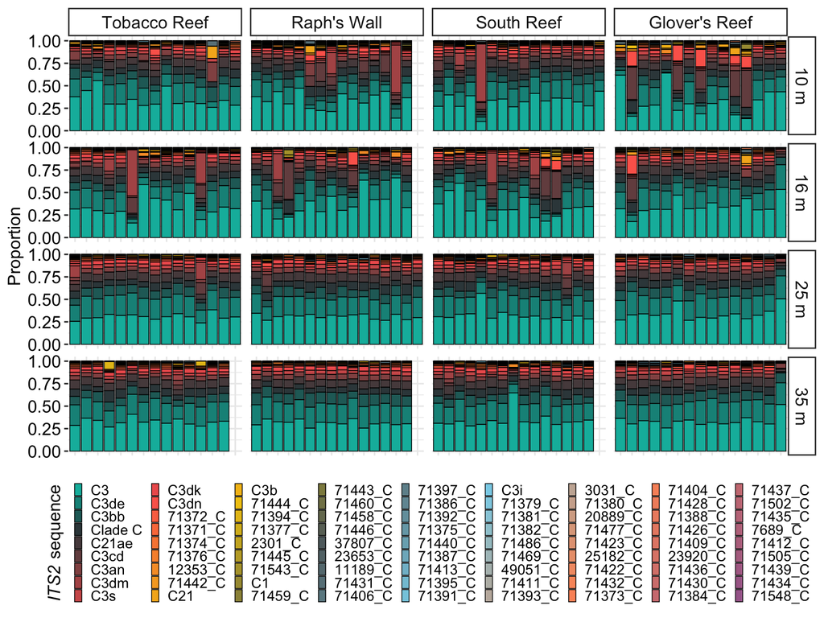

```r
ggsave("../figures/Fig3.eps", plot = its2SeqPlot, width = 8.5, height = 8.5, unit = "in", dpi = 600)
```

# *ITS2* type profiles

We can now look at the *ITS2* type profiles predicted by SymPortal.

## Prepare *ITS2* type profile data

Similar to what we did with the sequence data

```r
its2Profs = read.delim("62_20190310_DBV_2019-03-11_01-11-25.167036.profiles.absolute.clean.txt", header = TRUE, check.names = FALSE)
head(its2Profs)

its2Profs = cbind(its2Profs[1], its2MetaData[,2:3], its2Profs[,c(2:length(its2Profs))])
colnames(its2Profs)[3] = "Depth_zone"
head(its2Profs)

its2Profs$Depth_zone = factor(its2Profs$Depth_zone, levels = c("10", "16", "25", "35"))
levels(its2Profs$Depth_zone)

its2Profs$Sample_site = factor(its2Profs$Sample_site, levels(its2Profs$Sample_site)[c(4, 2, 3, 1)])
its2Profs = its2Profs[order(its2Profs$Sample_site, its2Profs$Depth_zone), ]
head(its2Profs)

sampleCounts = plyr::count(its2Profs, c('Sample_site','Depth_zone'))
meltedList = reshape2::melt(lapply(sampleCounts$freq,function(x){c(1:x)}))
its2Profs$barPlotOrder = meltedList$value
its2Profs=its2Profs[c(1,ncol(its2Profs),2:(ncol(its2Profs)-1))]
```

```r
head(its2Profs)
```

```
##      Sample barPlotOrder Sample_site Depth_zone A4/A4a B18b
## 107 CBC_107            1          TR         10      0    0
## 108 CBC_108            2          TR         10      0    0
## 109 CBC_109            3          TR         10      0    0
## 110 CBC_110            4          TR         10      0    0
## 111 CBC_111            5          TR         10      0    0
## 112 CBC_112            6          TR         10      0    0
##     C3-C3de-C3bb-C21ae-C3an-C3s-C3dk C3/C3dm-C3de-C3bb-C21ae-C3cd-C3an-C3s-C3dk
## 107                             4075                                          0
## 108                           173180                                          0
## 109                            11108                                          0
## 110                           166773                                          0
## 111                           152997                                          0
## 112                            17536                                          0
##     C3/C3cd-C3de-C3dn-C3bb-C21ae-C3an C21 C3-C3b C3cd/C3-C3dn C3cd
## 107                                 0   0      0            0    0
## 108                                 0   0      0            0    0
## 109                                 0   0      0            0    0
## 110                                 0   0      0            0    0
## 111                                 0   0      0            0    0
## 112                                 0   0      0            0    0
##     C3-C3de-C3an-C3bb-C21ae-C3s C3dm C1-C21 C3
## 107                           0    0      0  0
## 108                           0    0      0  0
## 109                           0    0      0  0
## 110                           0    0      0  0
## 111                           0    0      0  0
## 112                           0    0      0  0
```

## Normalization of *ITS2* type profile reads

Similar to what we did with the *ITS2* sequences, but we won’t purge any low abundance reads, since we only have 13 total *ITS2* type profiles.

```r
its2ProfsTransposed = t(its2Profs[, 5:length(its2Profs[1, ])])
its2ProfsList = DGEList(counts = its2ProfsTransposed)
head(its2ProfsList$samples)

its2ProfsNorm =  calcNormFactors(its2ProfsList, method = "TMM")
head(its2ProfsNorm$samples)
its2TMM = t(cpm(its2ProfsNorm, normalized.lib.sizes = TRUE))
its2ProfsNorm = cbind(its2Profs[,c(1:4)], its2TMM)
```

```r
head(its2ProfsNorm)
```

```
##      Sample barPlotOrder Sample_site Depth_zone A4/A4a B18b
## 107 CBC_107            1          TR         10      0    0
## 108 CBC_108            2          TR         10      0    0
## 109 CBC_109            3          TR         10      0    0
## 110 CBC_110            4          TR         10      0    0
## 111 CBC_111            5          TR         10      0    0
## 112 CBC_112            6          TR         10      0    0
##     C3-C3de-C3bb-C21ae-C3an-C3s-C3dk C3/C3dm-C3de-C3bb-C21ae-C3cd-C3an-C3s-C3dk
## 107                         994029.3                                          0
## 108                         994029.3                                          0
## 109                         994029.3                                          0
## 110                         994029.3                                          0
## 111                         994029.3                                          0
## 112                         994029.3                                          0
##     C3/C3cd-C3de-C3dn-C3bb-C21ae-C3an C21 C3-C3b C3cd/C3-C3dn C3cd
## 107                                 0   0      0            0    0
## 108                                 0   0      0            0    0
## 109                                 0   0      0            0    0
## 110                                 0   0      0            0    0
## 111                                 0   0      0            0    0
## 112                                 0   0      0            0    0
##     C3-C3de-C3an-C3bb-C21ae-C3s C3dm C1-C21 C3
## 107                           0    0      0  0
## 108                           0    0      0  0
## 109                           0    0      0  0
## 110                           0    0      0  0
## 111                           0    0      0  0
## 112                           0    0      0  0
```

## Preparing *ITS2* type profiles for plotting

```r
colOrder2 = order(colSums(its2ProfsNorm[5:length(its2ProfsNorm[1,])]), decreasing = TRUE) + 4

its2ProfsPerc = cbind(its2ProfsNorm[,c(1:4)],its2ProfsNorm[,c(colOrder2)])
its2ProfsPerc$sum = apply(its2ProfsPerc[, c(5:length(its2ProfsPerc[1,]))], 1, function(x) {
  sum(x, na.rm = T)
})

its2ProfsPerc = cbind(its2ProfsPerc[, c(1:4)], (its2ProfsPerc[, c(5:(ncol(its2ProfsPerc)-1))]
                                              / its2ProfsPerc$sum))
head(its2ProfsPerc)
```

```
##      Sample barPlotOrder Sample_site Depth_zone
## 107 CBC_107            1          TR         10
## 108 CBC_108            2          TR         10
## 109 CBC_109            3          TR         10
## 110 CBC_110            4          TR         10
## 111 CBC_111            5          TR         10
## 112 CBC_112            6          TR         10
##     C3-C3de-C3bb-C21ae-C3an-C3s-C3dk C3/C3dm-C3de-C3bb-C21ae-C3cd-C3an-C3s-C3dk
## 107                                1                                          0
## 108                                1                                          0
## 109                                1                                          0
## 110                                1                                          0
## 111                                1                                          0
## 112                                1                                          0
##     C3/C3cd-C3de-C3dn-C3bb-C21ae-C3an C3dm C3-C3de-C3an-C3bb-C21ae-C3s
## 107                                 0    0                           0
## 108                                 0    0                           0
## 109                                 0    0                           0
## 110                                 0    0                           0
## 111                                 0    0                           0
## 112                                 0    0                           0
##     C3cd/C3-C3dn C3-C3b C3cd C3 C21 C1-C21 A4/A4a B18b
## 107            0      0    0  0   0      0      0    0
## 108            0      0    0  0   0      0      0    0
## 109            0      0    0  0   0      0      0    0
## 110            0      0    0  0   0      0      0    0
## 111            0      0    0  0   0      0      0    0
## 112            0      0    0  0   0      0      0    0
```

```r
apply(its2ProfsPerc[, c(5:(ncol(its2ProfsPerc)))], 1, function(x) {
  sum(x, na.rm = T)
})
```

```
## 107 108 109 110 111 112 113 114 116 117 118 119 120 121 156  93  94  95  96  97
##   1   1   1   1   1   1   1   1   1   1   1   1   1   1   1   1   1   1   1   1
##  98  99 100 101 102 103 104 105 106 137 122 123 124 125 126 127 128 129 130 131
##   1   1   1   1   1   1   1   1   1   1   1   1   1   1   1   1   1   1   1   1
## 132 133 134 135 136 226 227 228 229 230 231 232 233 234 235 236 237 238 239  29
##   1   1   1   1   1   1   1   1   1   1   1   1   1   1   1   1   1   1   1   1
##  30  31  32  33  34  35  36  37  38  39  40  41  42  43  17  18  19  20  21  22
##   1   1   1   1   1   1   1   1   1   1   1   1   1   1   1   1   1   1   1   1
##  23  24  25  26  27  28  44  45  46   1   2   3   4   5   6   7   8   9  10  11
##   1   1   1   1   1   1   1   1   1   1   1   1   1   1   1   1   1   1   1   1
##  12  13  14  15  16 211 212 213 214 215 216 217 218 219 220 221 222 223 224 225
##   1   1   1   1   1   1   1   1   1   1   1   1   1   1   1   1   1   1   1   1
##  76  77  78  79  80  81  82  83  84  85  86  87  88  89  90  91  47  48  49  50
##   1   1   1   1   1   1   1   1   1   1   1   1   1   1   1   1   1   1   1   1
##  51  52  53  54  55  56  57  58  59  60  92  61  62  63  64  65  66  67  68  69
##   1   1   1   1   1   1   1   1   1   1   1   1   1   1   1   1   1   1   1   1
##  70  71  72  73  74  75 198 199 200 201 202 203 204 205 206 207 208 209 210 240
##   1   1   1   1   1   1   1   1   1   1   1   1   1   1   1   1   1   1   1   1
## 241 115 152 153 154 155 157 158 159 160 161 162 163 164 165 166 148 149 150 151
##   1   1   1   1   1   1   1   1   1   1   1   1   1   1   1   1   1   1   1   1
## 176 177 178 179 180 181 182 183 187 188 189 145 146 147 167 168 169 170 171 172
##   1   1   1   1   1   1   1   1   1   1   1   1   1   1   1   1   1   1   1   1
## 173 174 175 184 185 186 138 139 140 141 142 143 144 190 191 192 193 194 195 196
##   1   1   1   1   1   1   1   1   1   1   1   1   1   1   1   1   1   1   1   1
## 197
##   1
```

Again, everything looks good!

```r
gssProf = otuStack(its2ProfsPerc, count.columns = c(5:length(its2ProfsPerc[1, ])),
               condition.columns = c(1:4))[1:3133,] # remove summ rows

levels(gssProf$otu)

levels(gssProf$Depth_zone)
levels(gssProf$Depth_zone) = c("10 m", "16 m", "25 m", "35 m")
levels(gssProf$Sample_site)
levels(gssProf$Sample_site) = c("Tobacco Reef", "Raph's Wall", "South Reef", "Glover's Reef")
levels(gssProf$Depth_zone)
levels(gssProf$Sample_site)
```

## Consruct *ITS2* type profile barplot

```r
colorCount2 = length(c(4:length(its2ProfsPerc[1,]))) +1
getPalette2 = colorRampPalette(redmonder.pal(8, "qPBI"))

its2ProfsPlotA = ggplot(gssProf, aes(x = barPlotOrder, y = count, fill = factor(otu))) +
  geom_bar(position = "stack", stat = "identity", color = "black", size = 0.25) +
  ylab("Proportion") +
  scale_fill_manual(values = c(getPalette2(colorCount2)[2:12],
                               carto_pal(n = 7, "Tropic")[c(6,7)]))+
  labs(fill = expression(paste(italic("ITS2"), " type profile"))) +
  guides(fill = guide_legend(ncol = 2, reverse = FALSE)) +
  facet_grid(Depth_zone ~ Sample_site, scales = "free_x") + #faceting plots by Depth and Site
  theme_bw()

its2ProfsPlot = its2ProfsPlotA +
  theme(axis.title.x = element_blank(),
        axis.text.x = element_blank(),
        axis.ticks.x = element_blank(),
        axis.title.y = element_text(color = "black", size = 12),
        axis.text.y = element_text(color = "black", size = 12),
        legend.position = "bottom",
        legend.title = element_text(color = "black", size = 12, hjust = 0.5, angle = 90),
        legend.text = element_text(color = "black", size = 10),
        legend.key = element_blank(),
        legend.key.size = unit(0.75,"line"),
        legend.background = element_blank(),
        panel.border = element_blank(),
        panel.background = element_rect(fill = "white"),
        plot.background = element_blank(),
        strip.text.x = element_text(size = 12),
        strip.text.y = element_text(size = 12),
        strip.background = element_rect(fill = "white", size = 0.9)
  )

its2ProfsPlot
```

## Save *ITS2* type profile barplot

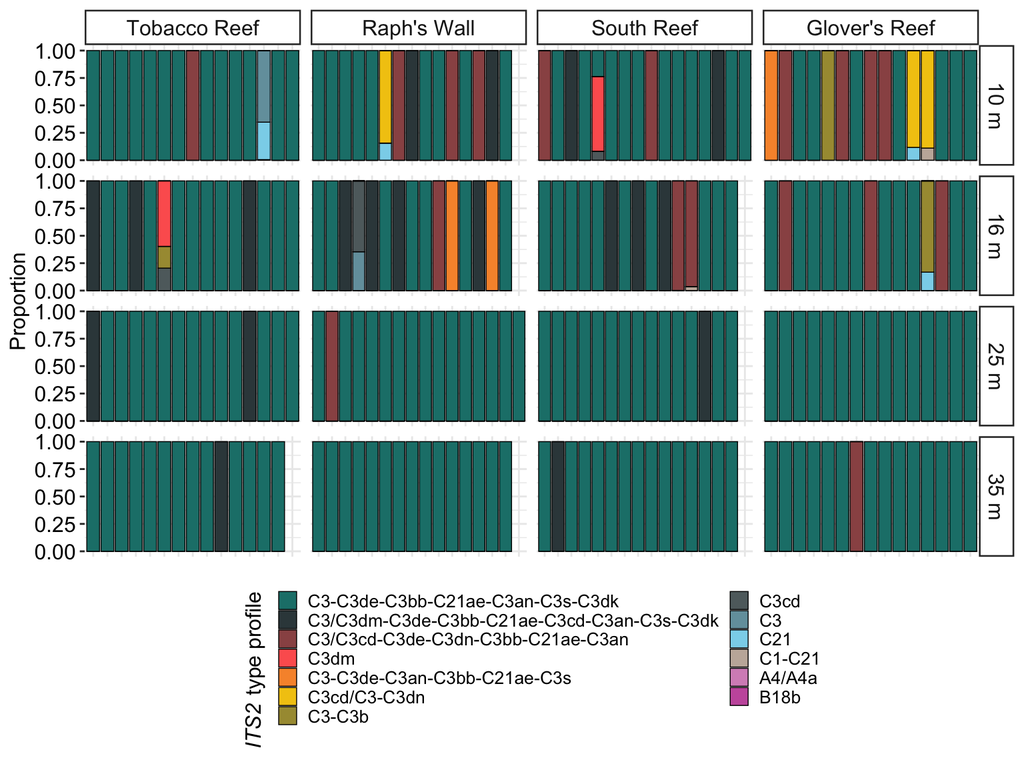

```r
ggsave("../figures/Fig4.eps", plot = its2ProfsPlot, width = 8.5, height = 8.5, unit = "in", dpi = 600)
```

# Statistical analyses on *ITS2* type profiles

## Cheking dispersion with PERMDISP

Using `betadisper()` in *vegan* to look at multivariate homogeneity of dispersion (PERMDISP) between sites and depths. This is using Bray-Curtis dissimilarity.

```r
set.seed(694) #setting seed allows repetition of randomized processes

its2dispS = betadisper(vegdist(its2ProfsNorm[, c(5:ncol(its2ProfsNorm))]), its2ProfsNorm$Sample_site)

anova(its2dispS)
```

```
## Analysis of Variance Table
##
## Response: Distances
##            Df Sum Sq  Mean Sq F value Pr(>F)
## Groups      3  0.283 0.094301  0.5837 0.6263
## Residuals 237 38.291 0.161566
```

No significant effect of Site on betadiversity.

```r
set.seed(694)

its2dispD = betadisper(vegdist(its2ProfsNorm[, c(6:ncol(its2ProfsNorm))]), its2ProfsNorm$Depth_zone)

anova(its2dispD)
```

```
## Analysis of Variance Table
##
## Response: Distances
##            Df Sum Sq Mean Sq F value       Pr(>F)
## Groups      3  4.926 1.64192  11.565 0.0000004215 ***
## Residuals 237 33.648 0.14198
## ---
## Signif. codes:  0 '***' 0.001 '**' 0.01 '*' 0.05 '.' 0.1 ' ' 1
```

Depth does significantly affect beta diversity.

### Permutation test for pairwise comparisons

Follow up with a permutation test to see where differences occur.

```r
set.seed(694)

its2PermTest = permutest(its2dispD, permutations = 9999, pairwise = T, model = "full", )
its2PermTest
```

```
##
## Permutation test for homogeneity of multivariate dispersions
## Permutation: free
## Number of permutations: 9999
##
## Response: Distances
##            Df Sum Sq Mean Sq      F N.Perm Pr(>F)
## Groups      3  4.926 1.64192 11.565   9999 0.0001 ***
## Residuals 237 33.648 0.14198
## ---
## Signif. codes:  0 '***' 0.001 '**' 0.01 '*' 0.05 '.' 0.1 ' ' 1
##
## Pairwise comparisons:
## (Observed p-value below diagonal, permuted p-value above diagonal)
##             10          16          25     35
## 10             0.887100000 0.000400000 0.0001
## 16 0.890151321             0.000100000 0.0001
## 25 0.000118583 0.000078099             0.7267
## 35 0.000045284 0.000029815 0.733416414
```

```r
its2PermTest$statistic
```

```
## Overall (F)   10-16 (t)   10-25 (t)   10-35 (t)   16-25 (t)   16-35 (t)
##  11.5648579  -0.1384088   3.9796639   4.2362895   4.0923225   4.3451550
##   25-35 (t)
##   0.3413910
```

## Running PERMANOVA in R

Now let’s see how different communities are from each other with PERMANOVA. We will utilize the `adonis()` function in *vegan*. We will use Bray-Curtis similarity for our distance matrix and run a total 0f 9,999 permutations, and test the effects of Site, Depth, and the interaction between Site and Depth. Dispersion is heteroschedastic, but PERMANOVA is robust to deviations in homgeneity of variance ( [Anderson and Walsh, 2013](https://esajournals.onlinelibrary.wiley.com/doi/10.1890/12-2010.1))

```r
set.seed(694)
its2Adonis = adonis(its2ProfsNorm[, c(5:ncol(its2ProfsNorm))] ~ Depth_zone * Sample_site,
data = its2ProfsNorm, permutations = 9999, method = "bray")

its2Adonis
```

```
##
## Call:
## adonis(formula = its2ProfsNorm[, c(5:ncol(its2ProfsNorm))] ~      Depth_zone * Sample_site, data = its2ProfsNorm, permutations = 9999,      method = "bray")
##
## Permutation: free
## Number of permutations: 9999
##
## Terms added sequentially (first to last)
##
##                         Df SumsOfSqs MeanSqs F.Model      R2 Pr(>F)
## Depth_zone               3     3.331 1.11039  6.8801 0.07925 0.0001 ***
## Sample_site              3     0.705 0.23497  1.4559 0.01677 0.1711
## Depth_zone:Sample_site   9     1.687 0.18740  1.1611 0.04012 0.2675
## Residuals              225    36.313 0.16139         0.86386
## Total                  240    42.036                 1.00000
## ---
## Signif. codes:  0 '***' 0.001 '**' 0.01 '*' 0.05 '.' 0.1 ' ' 1
```

PERMANOVA reveals that **Depth** has a signifcant effect on Symbiodiniaceae associations in our *M. cavernosa* samples.

### Pairwise PERMANOVA for multiple comparisons

Since we found that Depth was a significant factor in our PERMANOVA we can now use pairwise PERMANOVA to reveal where differences occur across depth. This utilizes the package *pairwiseAdonis*, where we will again use Bray-Curtis similarity and 9,999 permutations. We also have added false discovery rate (FDR) corrections since we are perfoming multiple comparisons.

```r
set.seed(694)
its2PWAdonis = pairwise.adonis(its2ProfsNorm[, c(5:ncol(its2ProfsNorm))],
                               factors = its2ProfsNorm$Depth_zone,
                               sim.method = "bray", p.adjust.m = "BH", perm = 9999)

its2PWAdonis
```

```
##      pairs Df   SumsOfSqs    F.Model          R2 p.value p.adjusted sig
## 1 10 vs 16  1 0.264839474  0.9837600 0.008199110  0.3709    0.44508
## 2 10 vs 25  1 1.491477086  9.0843560 0.070375344  0.0005    0.00075  **
## 3 10 vs 35  1 1.597044155 10.0260431 0.078312528  0.0002    0.00060  **
## 4 16 vs 25  1 1.573437103  9.4051037 0.073245560  0.0004    0.00075  **
## 5 16 vs 35  1 1.730759227 10.6563156 0.083476603  0.0001    0.00060  **
## 6 25 vs 35  1 0.006758822  0.1196029 0.001012558  1.0000    1.00000
```

We see that again see differences between our deeper (25 + 35 m) and shallower (10 + 16 m) samples.

## PERMANOVA without 35 m samples

First we need to remove the deep samples from the dataframe. We will use our dataframe of profiles that haven’t been normalized yet. This way we can calculate the normalization based on only the samples we are keeping in the analysis.

```r
its2Profs2 = subset(its2Profs, !Depth_zone=="35")
its2Profs2[] = lapply(its2Profs2, function(x) if(is.factor(x)) factor(x) else x)
summary(its2Profs2)
```

```r
head(its2Profs2)
```

```
##      Sample barPlotOrder Sample_site Depth_zone A4/A4a B18b
## 107 CBC_107            1          TR         10      0    0
## 108 CBC_108            2          TR         10      0    0
## 109 CBC_109            3          TR         10      0    0
## 110 CBC_110            4          TR         10      0    0
## 111 CBC_111            5          TR         10      0    0
## 112 CBC_112            6          TR         10      0    0
##     C3-C3de-C3bb-C21ae-C3an-C3s-C3dk C3/C3dm-C3de-C3bb-C21ae-C3cd-C3an-C3s-C3dk
## 107                             4075                                          0
## 108                           173180                                          0
## 109                            11108                                          0
## 110                           166773                                          0
## 111                           152997                                          0
## 112                            17536                                          0
##     C3/C3cd-C3de-C3dn-C3bb-C21ae-C3an C21 C3-C3b C3cd/C3-C3dn C3cd
## 107                                 0   0      0            0    0
## 108                                 0   0      0            0    0
## 109                                 0   0      0            0    0
## 110                                 0   0      0            0    0
## 111                                 0   0      0            0    0
## 112                                 0   0      0            0    0
##     C3-C3de-C3an-C3bb-C21ae-C3s C3dm C1-C21 C3
## 107                           0    0      0  0
## 108                           0    0      0  0
## 109                           0    0      0  0
## 110                           0    0      0  0
## 111                           0    0      0  0
## 112                           0    0      0  0
```

Normalize samples again, as above.

```r
its2ProfsTransposed2 = t(its2Profs2[, 5:length(its2Profs2[1, ])])
its2ProfsList2 = DGEList(counts = its2ProfsTransposed2)
head(its2ProfsList2$samples)

its2ProfsNorm2 =  calcNormFactors(its2ProfsList2, method = "TMM")
head(its2ProfsNorm2$samples)
its2TMM2 = t(cpm(its2ProfsNorm2, normalized.lib.sizes = TRUE))
its2ProfsNorm2 = cbind(its2Profs2[,c(1:4)], its2TMM2)
```

```r
head(its2ProfsNorm2)
```

```
##      Sample barPlotOrder Sample_site Depth_zone A4/A4a B18b
## 107 CBC_107            1          TR         10      0    0
## 108 CBC_108            2          TR         10      0    0
## 109 CBC_109            3          TR         10      0    0
## 110 CBC_110            4          TR         10      0    0
## 111 CBC_111            5          TR         10      0    0
## 112 CBC_112            6          TR         10      0    0
##     C3-C3de-C3bb-C21ae-C3an-C3s-C3dk C3/C3dm-C3de-C3bb-C21ae-C3cd-C3an-C3s-C3dk
## 107                         992101.4                                          0
## 108                         992101.4                                          0
## 109                         992101.4                                          0
## 110                         992101.4                                          0
## 111                         992101.4                                          0
## 112                         992101.4                                          0
##     C3/C3cd-C3de-C3dn-C3bb-C21ae-C3an C21 C3-C3b C3cd/C3-C3dn C3cd
## 107                                 0   0      0            0    0
## 108                                 0   0      0            0    0
## 109                                 0   0      0            0    0
## 110                                 0   0      0            0    0
## 111                                 0   0      0            0    0
## 112                                 0   0      0            0    0
##     C3-C3de-C3an-C3bb-C21ae-C3s C3dm C1-C21 C3
## 107                           0    0      0  0
## 108                           0    0      0  0
## 109                           0    0      0  0
## 110                           0    0      0  0
## 111                           0    0      0  0
## 112                           0    0      0  0
```

Run PERMANOVA on normalized subset of data

```r
set.seed(694)
its2AdonisNo35 = adonis(its2ProfsNorm2[, c(5:ncol(its2ProfsNorm2))] ~ Depth_zone * Sample_site,
                    data = its2ProfsNorm2, permutations = 9999, method = "bray")

its2AdonisNo35
```

```
##
## Call:
## adonis(formula = its2ProfsNorm2[, c(5:ncol(its2ProfsNorm2))] ~      Depth_zone * Sample_site, data = its2ProfsNorm2, permutations = 9999,      method = "bray")
##
## Permutation: free
## Number of permutations: 9999
##
## Terms added sequentially (first to last)
##
##                         Df SumsOfSqs MeanSqs F.Model      R2 Pr(>F)
## Depth_zone               2     2.222 1.11097  5.6348 0.05840 0.0005 ***
## Sample_site              3     0.873 0.29109  1.4764 0.02295 0.1576
## Depth_zone:Sample_site   6     1.432 0.23869  1.2106 0.03764 0.2537
## Residuals              170    33.518 0.19716         0.88100
## Total                  181    38.045                 1.00000
## ---
## Signif. codes:  0 '***' 0.001 '**' 0.01 '*' 0.05 '.' 0.1 ' ' 1
```

Depth is still has a significant effect on community structure

Let’ see where differences lie across depth using pairwise PERMANOVA again.

```r
set.seed(694)
its2PWAdonisNo35 = pairwise.adonis(its2ProfsNorm2[, c(5:ncol(its2ProfsNorm2))],
                               factors = its2ProfsNorm2$Depth_zone,
                               sim.method = "bray", p.adjust.m = "BH", perm = 9999)

its2PWAdonisNo35
```

```
##      pairs Df SumsOfSqs  F.Model         R2 p.value p.adjusted sig
## 1 10 vs 16  1 0.2648395 0.983760 0.00819911  0.3709    0.37090
## 2 10 vs 25  1 1.4914771 9.084356 0.07037534  0.0005    0.00075  **
## 3 16 vs 25  1 1.5734371 9.405104 0.07324556  0.0002    0.00060  **
```

The differences are still between 25 m and the shallower sites (10 + 16 m). This gives us confidence that temporal differences are not a cofactor with depth.

## SIMPER test between deep and shallow populations

Similarity percentage test (SIMPER) will show us the *ITS2* type profiles that contribute the most to the dissimilarity between depth zones

```r
depths = its2ProfsNorm$Depth_zone
levels(depths) = c("Shallow","Shallow","Deep","Deep")
depths
its2ProfsNorm$depth = depths
its2ProfsNorm = cbind(its2ProfsNorm[c(1:4)],its2ProfsNorm[ncol(its2ProfsNorm)],its2ProfsNorm[c(5:(ncol(its2ProfsNorm)-1))])
head(its2ProfsNorm)
```

```r
its2SimperD = simper(sqrt(its2ProfsNorm[, c(6:ncol(its2ProfsNorm))]), its2ProfsNorm$depth)
summary(its2SimperD)
```

```
##
## Contrast: Shallow_Deep
##
##                                              average       sd   ratio      ava
## C3-C3de-C3bb-C21ae-C3an-C3s-C3dk           0.1739207 0.233859 0.74370 659.1803
## C3/C3dm-C3de-C3bb-C21ae-C3cd-C3an-C3s-C3dk 0.0735606 0.176809 0.41604 115.3565
## C3/C3cd-C3de-C3dn-C3bb-C21ae-C3an          0.0716481 0.174440 0.41073 131.6755
## C3-C3de-C3an-C3bb-C21ae-C3s                0.0123967 0.077750 0.15944  24.7193
## C3cd/C3-C3dn                               0.0101081 0.063408 0.15941  23.0803
## C3-C3b                                     0.0087577 0.059117 0.14814  19.4279
## C21                                        0.0060702 0.033354 0.18199  14.2738
## C3dm                                       0.0056642 0.044231 0.12806  20.3637
## C3cd                                       0.0053058 0.035963 0.14753  15.2092
## C3                                         0.0047578 0.037056 0.12839  11.5608
## C1-C21                                     0.0019356 0.015391 0.12576   4.3170
## A4/A4a                                     0.0002471 0.002707 0.09128   0.6077
## B18b                                       0.0001825 0.001999 0.09128   0.3718
##                                               avb cumsum
## C3-C3de-C3bb-C21ae-C3an-C3s-C3dk           938.85 0.4643
## C3/C3dm-C3de-C3bb-C21ae-C3cd-C3an-C3s-C3dk  41.54 0.6607
## C3/C3cd-C3de-C3dn-C3bb-C21ae-C3an           16.62 0.8520
## C3-C3de-C3an-C3bb-C21ae-C3s                  0.00 0.8851
## C3cd/C3-C3dn                                 0.00 0.9121
## C3-C3b                                       0.00 0.9355
## C21                                          0.00 0.9517
## C3dm                                         0.00 0.9668
## C3cd                                         0.00 0.9810
## C3                                           0.00 0.9937
## C1-C21                                       0.00 0.9989
## A4/A4a                                       0.00 0.9995
## B18b                                         0.00 1.0000
## Permutation: free
## Number of permutations: 0
```